# Chapter2. NumPy数组

NumPy，是Numerical Python的简称，它是目前Python数值计算中最为重要的基础包。NumPy本身并不提供建模和科学函数，但大多数其它计算包（比如pandas）都提供了基于NumPy的科学函数功能，将NumPy的数组对象（ndarray：多维数组对象）作为数据交换的通用语。因此，理解NumPy的数组以及基于数组的计算将更有效地使用基于数组的工具。NumPy之所以如此重要，主要原因包括：

1. NumPy对于含有大量数组的数据非常有效：
2. NumPy数组使用的内存量小于其它Python内建序列，运行速度更快；
3. NumPy可以针对全量数组进行复杂计算而不需要写Python循环。

## 引例 An Example

NumPy ndarray - 多维数组对象 VS. Python内建数据结构

```python
# 如何将两个列表的值相加，得到一个同尺寸的新列表？
a = [1,2,3,4,5]
b = [10,11,12,13,14]
a + b
```

```
[1, 2, 3, 4, 5, 10, 11, 12, 13, 14]
```

```python
# 方法1：使用循环
ls = []
for x,y in zip(a,b):
    ls.append(x+y)
ls
```

```
[11, 13, 15, 17, 19]
```

```python
# 方法2：使用列表推导式
[x+y for x,y in zip(a,b)]
```

```
[11, 13, 15, 17, 19]
```

```python
# 数组：针对数组中的每个元素进行计算而不需要写for循环
import numpy as np
a_arr = np.array(a)
b_arr = np.array(b)
a_arr + b_arr
```

```
array([11, 13, 15, 17, 19])
```

```python
a_arr * b_arr
```

```
array([10, 22, 36, 52, 70])
```

```python
# 对比运行速度
ls = list(range(1000000))  # 列表
arr = np.arange(1000000)   # 数组
```

```python
%time ls2 = [i*2 for i in ls]
```

```
CPU times: user 64.2 ms, sys: 161 ms, total: 225 ms
Wall time: 47.3 ms
```

```python
%time arr2 = arr*2
```

```
CPU times: user 2.59 ms, sys: 8.67 ms, total: 11.3 ms
Wall time: 3 ms
```

## 2.1 生成数组 Array Creation

### 2.1.1 array函数和常用属性

`array()`函数接收任意的序列型对象(列表、元组等)，生成一个新的NumPy数组。

```python
import numpy as np
data1 = [1, 2.1, 3.2, 4]
arr1 = np.array(data1)  # 一维数组
arr1
```

```
array([1. , 2.1, 3.2, 4. ])
```

```python
data2 = [[1,2,3,4],[5,6,7,8]]  # 嵌套列表
arr2 = np.array(data2)  # 二维数组
arr2
```

```
array([[1, 2, 3, 4],
       [5, 6, 7, 8]])
```

```python
# 查看数据类型
type(arr2)
```

```
numpy.ndarray
```

```python
# tolist()方法：将数组转化为Python列表
ls = arr2.tolist()
ls
```

```
[[1, 2, 3, 4], [5, 6, 7, 8]]
```

```python
type(ls)
```

```
list
```

```python
# ndim属性：描述数组的维度
arr1.ndim
```

```
1
```

```python
arr2.ndim
```

```
2
```

```python
# shape属性：描述数组每一维度的数量，返回一个元组
arr1.shape
```

```
(4,)
```

```python
arr2.shape  # 第一个维度看作行，第二个维度看作列
```

```
(2, 4)
```

```python
# size属性：描述数组中元素的数量
arr1.size
```

```
4
```

```python
arr2.size
```

```
8
```

```python
# dtype属性：描述数组中元素的数据类型，同一个ndarray中包含的元素均为相同类型
# 关于数据类型我们只需了解大类，比如浮点型、整数、布尔值、字符串（较少）等
arr1.dtype
```

```
dtype('float64')
```

```python
arr2.dtype
```

```
dtype('int64')
```

```python
# astype方法：显性地转换数组的数据类型
arr1.astype('int32')  # 将浮点数转换成整数，则小数点后的部分将被消除
```

```
array([1, 2, 3, 4], dtype=int32)
```

```python
arr2.astype('float64')  # 将整数转换成浮点数
```

```
array([[1., 2., 3., 4.],
       [5., 6., 7., 8.]])
```

### 2.1.2 arange函数和linspace函数

`arange()`函数相当于Python内建函数`range()`的数组版，返回一个数组。

当`arange()`函数用于浮点数数组时通常难以确定元素的数量，这时`linspace()`是一个不错的选择，将`step`参数替换为元素个数`num`。

```python
np.arange(20)
```

```
array([ 0,  1,  2,  3,  4,  5,  6,  7,  8,  9, 10, 11, 12, 13, 14, 15, 16,
       17, 18, 19])
```

```python
np.arange(10,50,4)
```

```
array([10, 14, 18, 22, 26, 30, 34, 38, 42, 46])
```

```python
# 联合使用reshape()方法
np.arange(20).reshape((4,5))
```

```
array([[ 0,  1,  2,  3,  4],
       [ 5,  6,  7,  8,  9],
       [10, 11, 12, 13, 14],
       [15, 16, 17, 18, 19]])
```

```python
# 使用linspace()函数可以明确数组元素的个数
np.linspace(10,50,15)
```

```
array([10.        , 12.85714286, 15.71428571, 18.57142857, 21.42857143,
       24.28571429, 27.14285714, 30.        , 32.85714286, 35.71428571,
       38.57142857, 41.42857143, 44.28571429, 47.14285714, 50.        ])
```

### 2.1.3 其它数组生成函数

有时只知道数组的size但并不确定每个元素，因此NumPy提供了其它使用初始占位符生成数组的函数。

```python
# zeros()函数：一次性生成全0数组
np.zeros(10)
```

```
array([0., 0., 0., 0., 0., 0., 0., 0., 0., 0.])
```

```python
# ones()函数：一次性生成全1数组
np.ones([3,6])  # 创建多维数组需要为shape参数传递一个元组，默认的数据类型dtype为float64
```

```
array([[1., 1., 1., 1., 1., 1.],
       [1., 1., 1., 1., 1., 1.],
       [1., 1., 1., 1., 1., 1.]])
```

```python
# empty()函数：创建一个没有初始化数值的数组
np.empty([2,3,2],dtype='int8') # 随机生成
```

```
array([[[ 0,  0],
        [ 0,  0],
        [ 0,  0]],

       [[ 0,  0],
        [25,  0],
        [ 0,  0]]], dtype=int8)
```

```python
# eye()函数：创建一个二维数组，其对角线为1，其余元素为0
np.eye(5)
```

```
array([[1., 0., 0., 0., 0.],
       [0., 1., 0., 0., 0.],
       [0., 0., 1., 0., 0.],
       [0., 0., 0., 1., 0.],
       [0., 0., 0., 0., 1.]])
```

```python
# full()函数：创建一个指定填充值的数组
np.full([2,3],6)
```

```
array([[6, 6, 6],
       [6, 6, 6]])
```

### 2.1.4 生成随机数组

使用NumPy的`random`模块中的函数可以生成随机数组。

```python
# rand()方法可以生成给定shape的[0,1)之间随机浮点数
np.random.rand(4,5)
```

```
array([[0.14330711, 0.8043574 , 0.75184937, 0.67652632, 0.2408517 ],
       [0.82611701, 0.23377954, 0.21145951, 0.26129753, 0.21489287],
       [0.01901767, 0.67170103, 0.77074352, 0.01526965, 0.24906634],
       [0.61031489, 0.68323741, 0.23020443, 0.30466871, 0.81954473]])
```

```python
# randn()方法可以生成服从正态分布（均值0，方差1）的随机浮点数
np.random.randn(4,5)
```

```
array([[ 0.8702867 ,  0.63137807,  0.55002008,  0.38416075,  0.94133477],
       [-1.02527602, -0.05848439, -0.97978507, -0.3785402 ,  0.4800682 ],
       [-0.74655312, -0.45089344, -1.05151876, -0.300932  ,  0.04898615],
       [-2.7158875 ,  2.67282209,  0.34128086,  0.85824251,  0.17287358]])
```

```python
# 可视化randn()生成的随机浮点数
import matplotlib.pyplot as plt
import matplotlib_inline

x = np.random.randn(100)
fig, axs = plt.subplots(nrows=1,ncols=2,figsize=(8,3))
axs[0].plot(x,'ro')
axs[0].plot(x+5,'co')
axs[1].hist(x)

matplotlib_inline.backend_inline.set_matplotlib_formats('svg')
```

[figure not shown]

```python
# randint()方法可以生成给定范围和数量的随机整数
np.random.randint(0,10,size=(2,3))
```

```
array([[5, 3, 3],
       [8, 9, 3]])
```

## 2.2 索引与切片 Indexing and Slicing

### 2.2.1 一维数组

```python
import numpy as np
arr1 = np.arange(10)  # 一维数组
arr1
```

```
array([0, 1, 2, 3, 4, 5, 6, 7, 8, 9])
```

```python
arr2 = np.array([[1,2],[3,4],[5,6]])
arr2
```

```
array([[1, 2],
       [3, 4],
       [5, 6]])
```

```python
# 索引
arr1[5]
```

```
5
```

```python
# 切片
arr1[5:8]
```

```
array([5, 6, 7])
```

```python
arr1[:5:2]
```

```
array([0, 2, 4])
```

```python
# 赋值
arr1[5:8]=12
arr1  # 传入的一个数值将会被传递给整个切片，数组的切片是原数组的视图，任何对于视图的修改都会反映到原数组上
```

```
array([ 0,  1,  2,  3,  4, 12, 12, 12,  8,  9])
```

```python
# VS.列表的赋值
ls = list(range(10))
ls[5:8]=[12]
ls
```

```
[0, 1, 2, 3, 4, 12, 8, 9]
```

```python
arr1.dtype  # 查看arr1元素的数据类型
```

```
dtype('int64')
```

```python
arr1[5]=10.5  # 给int数组赋值float会被截断
arr1
```

```
array([ 0,  1,  2,  3,  4, 10, 12, 12,  8,  9])
```

### 2.2.2 二维数组

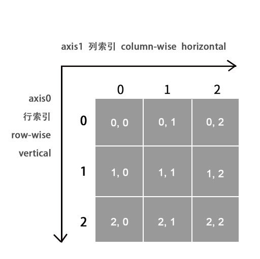

```python
arr2 = np.array([[1,2,3],[4,5,6],[7,8,9]])  # 二维数组有两个轴axis，每个轴都有索引
arr2
```

```
array([[1, 2, 3],
       [4, 5, 6],
       [7, 8, 9]])
```

```python
# 索引：二维数组中，每个索引值对应的元素不再是一个值，而是一个一维数组
arr2[2]
```

```
array([7, 8, 9])
```

```python
# 若要定位到单个元素，需传递一个用逗号分隔的索引列表
arr2[0,2]  # 第一个轴axis0看作是行，第二个轴axis1看作是列
```

```
3
```

```python
arr2[0][2]  # 也可以使用该写法进行索引，但不推荐
```

```
3
```

```python
# 切片
arr2[:2]  # 沿着axis0-行 进行切片，即前两行
```

```
array([[1, 2, 3],
       [4, 5, 6]])
```

```python
arr2[:,:2]  # 沿着axis1-列 进行切片，即前两列
```

```
array([[1, 2],
       [4, 5],
       [7, 8]])
```

```python
# 多组切片
arr2[:2,1:]
```

```
array([[2, 3],
       [5, 6]])
```

```python
# 索引与切片混合
arr2[1,:2]
```

```
array([4, 5])
```

```python
# 循环
for row in arr2:
    print(row)  # 按axis0循环输出
```

```
[1 2 3]
[4 5 6]
[7 8 9]
```

```python
# 循环输出每个元素
for ele in arr2.flat:
    print(ele, end=' ')  # flat属性是数组中每个元素的迭代器
```

```
1 2 3 4 5 6 7 8 9
```

### 2.2.3 多维数组

```python
arr3 = np.array([[[1,2,3],[4,5,6]],[[7,8,9],[10,11,12]]])  # 三维数组
arr3
```

```
array([[[ 1,  2,  3],
        [ 4,  5,  6]],

       [[ 7,  8,  9],
        [10, 11, 12]]])
```

```python
arr3.ndim  # 查看数组的维度
```

```
3
```

```python
arr3.shape  # 查看数组每一维度的数量
```

```
(2, 2, 3)
```

```python
# 索引：省略后续索引值，返回的对象将是降低一个维度的数组
arr3[0]  # 返回的是一个二维数组
```

```
array([[1, 2, 3],
       [4, 5, 6]])
```

```python
arr3[1,0]  # 返回的是一个一维数组
```

```
array([7, 8, 9])
```

```python
arr3[1,0,2]  # 返回一个元素
```

```
9
```

### 2.2.4 布尔索引

使用布尔值数组进行索引

```python
import numpy as np
arr = np.arange(10)
arr
```

```
array([0, 1, 2, 3, 4, 5, 6, 7, 8, 9])
```

```python
arr[arr<5]
```

```
array([0, 1, 2, 3, 4])
```

```python
names = np.array(['Bob','Joe','Will','Bob','Will','Joe','Joe'])  # 由重复字符串列表构成的数组
names == 'Bob'  # 数组的比较操作（比如==）也是可以向量化的
```

```
array([ True, False, False,  True, False, False, False])
```

```python
data = np.random.randint(50,100,size=(7,4))
data
```

```
array([[69, 50, 67, 90],
       [84, 89, 53, 87],
       [64, 62, 84, 72],
       [93, 62, 90, 79],
       [97, 93, 72, 89],
       [88, 81, 56, 52],
       [90, 99, 75, 63]])
```

```python
data[data%2==0]
```

```
array([50, 90, 84, 64, 62, 84, 72, 62, 90, 72, 88, 56, 52, 90])
```

```python
# 布尔索引：现假设每个人名和data数组中的一行相对应，在索引数组时传入布尔值数组（布尔值数组的长度必须和数组轴索引长度一致）
data[names == 'Bob']
```

[output not shown]

```python
data[:,[True,False,True,False]]
```

```
array([[69, 67],
       [84, 53],
       [64, 84],
       [93, 90],
       [97, 72],
       [88, 56],
       [90, 75]])
```

```python
data[names == 'Bob',:2]  # 还可以继续索引列
```

[output not shown]

```python
# 取反：使用！=或在条件表达式前使用~对条件取反
data[names != 'Bob']
data[~(names == 'Bob')]
```

[output not shown]

```python
# 多条件：使用&或者|对多个条件表达式进行联合
data[(names == 'Bob')| (names == 'Will')]
```

[output not shown]

### 2.2.5 神奇索引

使用整数数组进行索引。

```python
# 创建一个二维数组
arr = np.arange(32).reshape(8,4)
arr
```

```
array([[ 0,  1,  2,  3],
       [ 4,  5,  6,  7],
       [ 8,  9, 10, 11],
       [12, 13, 14, 15],
       [16, 17, 18, 19],
       [20, 21, 22, 23],
       [24, 25, 26, 27],
       [28, 29, 30, 31]])
```

```python
# 创建一个索引数组
index1 = np.array([2,0])
index1
```

```
array([2, 0])
```

```python
# 神奇索引：通过传递一个整数数组来筛选出一个符合特定顺序的子集
arr[index1]
```

```
array([[ 8,  9, 10, 11],
       [ 0,  1,  2,  3]])
```

```python
# 如果使用负索引，将从尾部进行选择
index2 = np.array([-1,-3])
arr[index2]
```

```
array([[28, 29, 30, 31],
       [20, 21, 22, 23]])
```

```python
# 传递多个索引数组，会根据每个索引对应的元素选出一个一维数组，与切片不同
arr[index1,index2]  # 选中的元素是(2,-1)和(0,-3)
```

```
array([11,  1])
```

## 2.3 数组基本运算 Basic Operations

### 2.3.1 数组算术

数组可以进行批量操作，而无须任何for循环，NumPy将这种特征称为向量化。任何在两个等尺寸数组之间的算术操作都应用了逐元素(elementwise)的操作方式，并返回一个计算后的新的数组。

```python
import numpy as np
arr = np.array([[1,2,3,4],[5,6,7,8]])  # 二维数组
arr
```

```
array([[1, 2, 3, 4],
       [5, 6, 7, 8]])
```

```python
arr + arr  # 逐元素相加，返回一个新数组
```

```
array([[ 2,  4,  6,  8],
       [10, 12, 14, 16]])
```

```python
arr += arr  # 不会创建一个新数组，修改当前数组arr的值
# arr = arr + arr  # 相当于相加后再赋值
arr
```

```
array([[ 2,  4,  6,  8],
       [10, 12, 14, 16]])
```

```python
arr - 5  # 逐元素减去5
```

```
array([[-3, -1,  1,  3],
       [ 5,  7,  9, 11]])
```

```python
arr * arr  # NumPy中的*是逐元素相乘，而不是矩阵中的点乘
```

```
array([[  4,  16,  36,  64],
       [100, 144, 196, 256]])
```

```python
arr.dot(np.ones((4,2)))  # 点乘需要用到dot函数
```

[output not shown]

```python
1 / arr
```

```
array([[0.5       , 0.25      , 0.16666667, 0.125     ],
       [0.1       , 0.08333333, 0.07142857, 0.0625    ]])
```

```python
arr ** 0.5
```

```
array([[1.41421356, 2.        , 2.44948974, 2.82842712],
       [3.16227766, 3.46410162, 3.74165739, 4.        ]])
```

### 2.3.2 通用函数

通用函数Universal Functions，简称ufunc，是NumPy提供的一种在ndarray数据中快速进行逐元素操作的函数，是对一些常用的简单函数的向量化封装。

#### ① 一元通用函数

接收一个数组并返回一个数组作为结果，常见的一元通用函数包括：

1. abs\fabs：逐元素计算整数、浮点数的绝对值
2. sqrt：计算每个元素的平方根
3. square：计算每个元素的平方
4. exp：计算每个元素的自然指数值
5. log\log10\log2\log1p：分别计算自然对数、对数10为底、对数2为底、log(1+x)
6. ceil\floor：将元素向上、向下取整
7. rint：将元素保留到整数位
8. sin\cos\tan：常规的双曲三角函数
9. arcsin\arccos\arctan：常规的反三角函数

```python
arr = np.arange(10)
arr
```

```
array([0, 1, 2, 3, 4, 5, 6, 7, 8, 9])
```

```python
# sqrt函数：计算每个元素的平方根
np.sqrt(arr)
```

```
array([0.        , 1.        , 1.41421356, 1.73205081, 2.        ,
       2.23606798, 2.44948974, 2.64575131, 2.82842712, 3.        ])
```

```python
# square函数：计算每个元素的平方
np.square(arr)
```

```
array([ 0,  1,  4,  9, 16, 25, 36, 49, 64, 81], dtype=int32)
```

#### ② 二元通用函数

接收两个数组并返回一个数组作为结果，常见的二元通用函数包括：

1. add：将数组的对应元素相加；
2. multiply：将数组的对应元素相乘；
3. divide,floor_divide：除或整除；
4. maximum\minimum：逐个元素计算最大值\最小值；
5. mod：逐元素求模计算；

```python
a = np.random.randint(10,size=5)
a
```

```
array([0, 3, 5, 9, 8])
```

```python
b = np.random.randint(10,size=5)
b
```

```
array([7, 2, 9, 7, 4])
```

```python
# add函数：将数组的对应元素相加
np.add(a,b)
# a + b  # 等同于算术
```

```
array([ 7,  5, 14, 16, 12])
```

```python
# maximum函数：逐个元素计算最大值
np.maximum(a,b)
```

```
array([7, 3, 9, 9, 8])
```

### 2.3.3 数组统计方法

许多关于计算整个数组统计值或关于轴向数据的数学函数，可以作为数组类型的方法被调用。

常见的数组统计方法包括：

1. sum：沿着轴向计算所有元素的累和；
2. mean：计算平均值；
3. std/var：计算标准差和方差；
4. min/max：计算最小值和最大值；
5. argmin/argmax：返回最小值和最大值的索引位；
6. cumsum：从0开始元素累计和；
7. cumprod：从1开始元素累计积。

```python
arr = np.arange(20).reshape(4,5)
arr
```

```
array([[ 0,  1,  2,  3,  4],
       [ 5,  6,  7,  8,  9],
       [10, 11, 12, 13, 14],
       [15, 16, 17, 18, 19]])
```

```python
# 计算平均值
arr.mean()
# np.mean(arr)  # 另一种写法
```

```
9.5
```

```python
# 可选参数axis用于计算给定轴向上的统计值，形成一个下降一维度的数组
arr.mean(axis=0)  # 沿axis0轴计算平均值
```

```
array([ 7.5,  8.5,  9.5, 10.5, 11.5])
```

```python
arr.mean(axis=1)  # 沿axis1轴计算平均值
```

```
array([ 2.,  7., 12., 17.])
```

```python
# 累计和
arr.cumsum()  # 并不会聚合，返回一个相同长度的数组
```

```
array([  0,   1,   3,   6,  10,  15,  21,  28,  36,  45,  55,  66,  78,
        91, 105, 120, 136, 153, 171, 190], dtype=int32)
```

```python
# 指定轴向上根据较低维度的切片进行部分聚合
arr.cumsum(axis=1)  # 沿1轴-列 返回列方向上的累计和
```

```
array([[ 0,  1,  3,  6, 10],
       [ 5, 11, 18, 26, 35],
       [10, 21, 33, 46, 60],
       [15, 31, 48, 66, 85]], dtype=int32)
```

### 2.3.4 数组集合操作

NumPy中包含一些针对一维数组的基础集合操作，常见的集合操作包括：

1. unique(x)：计算x的唯一值，并排序；
2. intersect1d(x,y)：计算x和y的交集，并排序；
3. union1d(x,y)：计算x和y的并集，并排序；
4. in1d(x,y)：计算x中的元素是否包含在y中，返回一个布尔值数组；
5. setdiff1d(x,y)：差集，在x中但不在y中的x的元素；
6. setxor1d(x,y)：异或集，在x或y中，但不属于xy交集的元素。

```python
names = np.array(['Bob','Joe','Will','Bob','Will','Joe','Joe'])  # 由重复字符串列表构成的数组
np.unique(names)
```

```
array(['Bob', 'Joe', 'Will'], dtype='<U4')
```

```python
arr = np.arange(10)
np.in1d([6,8,10], arr)  # 判断[6,8,10]是否包含在arr中
```

```
array([ True,  True, False])
```

## 2.4 数据重组 Shape Manipulation

### 2.4.1 改变数组形状

```python
arr = np.arange(12).reshape(3,4)
arr
```

```
array([[ 0,  1,  2,  3],
       [ 4,  5,  6,  7],
       [ 8,  9, 10, 11]])
```

```python
arr.shape
```

```
(3, 4)
```

```python
# ravel()方法：将元素以一维数组的形式返回
arr.ravel()
```

```
array([ 0,  1,  2,  3,  4,  5,  6,  7,  8,  9, 10, 11])
```

```python
# reshape()方法：将数组以新的shape返回
arr.reshape(2,6)
```

```
array([[ 0,  1,  2,  3,  4,  5],
       [ 6,  7,  8,  9, 10, 11]])
```

```python
arr.reshape(-1)  # 等同于ravel()方法
```

```
array([ 0,  1,  2,  3,  4,  5,  6,  7,  8,  9, 10, 11])
```

```python
# resize()方法与reshape()方法类似，但会对原数组产生变化，因此不建议使用
arr.resize(2,6)
arr
```

```
array([[ 0,  1,  2,  3,  4,  5],
       [ 6,  7,  8,  9, 10, 11]])
```

```python
# T属性：对于二维数组，使用T属性实现转置
arr.T
```

```
array([[ 0,  4,  8],
       [ 1,  5,  9],
       [ 2,  6, 10],
       [ 3,  7, 11]])
```

```python
# transpose()方法：对于高维数组，transpose方法可以接收包含轴编号的元组，用于置换轴
arr3 = np.arange(24).reshape(2,3,4)
arr3
```

```
array([[[ 0,  1,  2,  3],
        [ 4,  5,  6,  7],
        [ 8,  9, 10, 11]],

       [[12, 13, 14, 15],
        [16, 17, 18, 19],
        [20, 21, 22, 23]]])
```

```python
arr3.transpose((1,0,2))  # 0轴和1轴进行了置换
```

```
array([[[ 0,  1,  2,  3],
        [12, 13, 14, 15]],

       [[ 4,  5,  6,  7],
        [16, 17, 18, 19]],

       [[ 8,  9, 10, 11],
        [20, 21, 22, 23]]])
```